# Prognozowanie szeregów czasowych

```python
import warnings

warnings.simplefilter(action="ignore", category=FutureWarning)
warnings.simplefilter(action="ignore", category=UserWarning)

import matplotlib.pyplot as plt
import numpy as np
import pandas as pd
```

Naszą główną biblioteką do szeregów czasowych będzie [sktime](https://www.sktime.net/en/stable/index.html), oferujące interfejs podobny do Scikit-learn. Jest to wrapper na wiele innych bibliotek, między innymi:

- statsforecast - wydajna implementacja wielu metod prognozowania, m.in. AutoARIMA i AutoETS
- [pmdarima](https://alkaline-ml.com/pmdarima/) - testy statystyczne dla szeregów czasowych oraz alternatywna implementacja AutoARIMA
- [statsmodels](https://www.statsmodels.org/stable/index.html) - niektóre metody dekompozycji szeregów czasowych i prognozowania

Do obliczania testów statystycznych wykorzystamy [scipy](https://docs.scipy.org/doc/scipy/index.html) oraz [statsmodels](https://www.statsmodels.org/stable/index.html).

## Prognozowanie inflacji w Polsce

W Polsce podstawowe dane o inflacji [publikuje Główny Urząd Statystyczny (GUS)](https://stat.gov.pl/obszary-tematyczne/ceny-handel/wskazniki-cen/wskazniki-cen-towarow-i-uslug-konsumpcyjnych-pot-inflacja-/miesieczne-wskazniki-cen-towarow-i-uslug-konsumpcyjnych-od-1982-roku/), z częstotliwością miesięczną, kwartalną, półroczną i roczną. Bardziej szczegółowe informacje publikują inne instytucje, bo zależą od przyjętej metodyki, np. inflację bazową [oblicza i publikuje Narodowy Bank Polski (NBP)](https://nbp.pl/statystyka-i-sprawozdawczosc/inflacja-bazowa/).

Prognozowanie inflacji jest wyzwaniem, bo typowo inflacja:

- ma wyraźne cykle, ale wysoce nieregularne
- jest implicite związana z wieloma czynnikami zewnętrznymi (gospodarka światowa, decyzje polityczne etc.)
- nie ma wyraźnej sezonowości
- interesuje nas prognozowanie na wielu poziomach szczególowości, np. miesięczne, kwartalne, roczne

Zajmiemy się danymi z GUS, o częstotliwości miesięcznej. Aby otrzymać inflację rok do roku (RDR), z którą typowo mamy do czynienia, trzeba odjąć 100 od podawanych wartości.

```python
df = pd.read_csv("polish_inflation.csv")
df = df.rename(columns={"Rok": "year", "Miesiąc": "month", "Wartość": "value"})

# create proper date column
df["day"] = 1
df["date"] = pd.to_datetime(df[["year", "month", "day"]])
df["date"] = df["date"].dt.to_period("M")

# set datetime index
df = df.set_index(df["date"], drop=True)
df = df.sort_index()

# leave only time series values
df = df["value"] - 100
df
```

```
date
1982-01     53.2
1982-02    106.4
1982-03    110.7
1982-04    104.1
1982-05    108.4
           ...
2023-11      6.6
2023-12      6.2
2024-01      3.7
2024-02      2.8
2024-03      2.0
Freq: M, Name: value, Length: 507, dtype: float64
```

Do rysowania szeregów czasowych najłatwiej użyć funkcji `plot_series` z sktime, która ustawi nam od razu ładnie opisy na osi X.

```
(<Figure size 1600x400 with 1 Axes>, <Axes: ylabel='value'>)
```

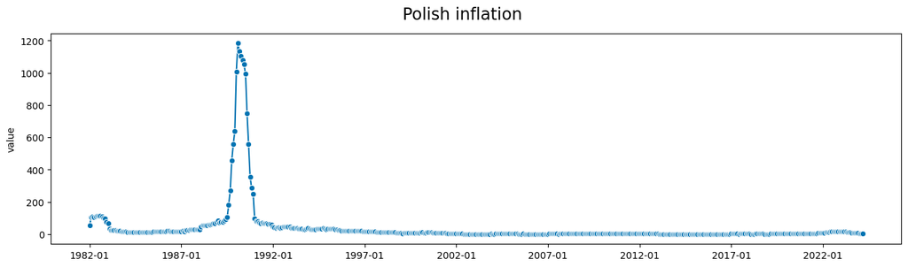

```python
from sktime.utils.plotting import plot_series

plot_series(df, title="Polish inflation")
```

Tu nie ma błędu - lata 90 były ciekawym okresem, z [hiperinflacją](https://pl.wikipedia.org/wiki/Hiperinflacja#Polska_%E2%80%93_lata_80._XX_wieku), późniejszą terapią szokową i realizacją [planu Balcerowicza](https://pl.wikipedia.org/wiki/Plan_Balcerowicza). Z perspektywy prognozowania szeregów czasowych jest to ewidentny outlier, ale przy tym bardzo długi. W związku z tym ograniczymy się do późniejszego okresu, od roku 2000.

```
(<Figure size 1600x400 with 1 Axes>, <Axes: ylabel='value'>)
```

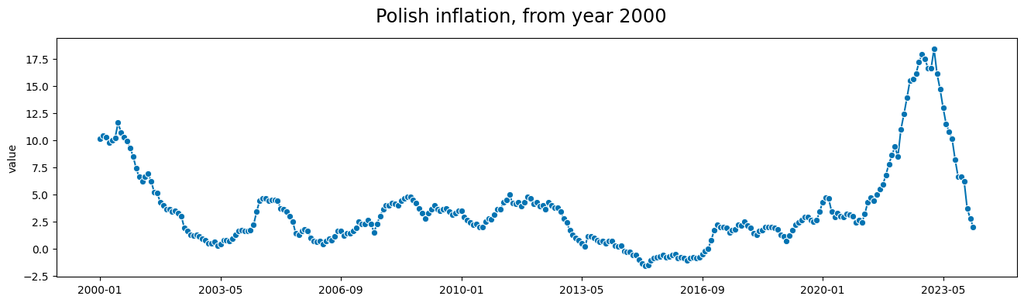

```python
df = df[df.index >= "2000-01"]
plot_series(df, title="Polish inflation, from year 2000")
```

Już "na oko" widać tutaj ewidentne cykle i trendy. Natomiast są też dobre wieści - inflacja jest dość łagodnie zmiennym agregatem. Pytanie, co z sezonowością?

**Zadanie 1 (0.5 punktu)**

Uzupełnij kod funkcji `plot_stl_decomposition`. Wykorzystaj `STLTransformer` do obliczenia dekompozycji STL ([dokumentacja](https://www.sktime.net/en/v0.29.0/api_reference/auto_generated/sktime.transformations.series.detrend.STLTransformer.html)). Pamiętaj o podaniu odpowiednich opcji, aby uwzględnić podany okres sezonowości, i zwrócić wszystkie trzy komponenty.

Następnie narysuj dekompozycję STL dla danych o inflacji. Skomentuj:

- czy twoim zdaniem widać tutaj roczną sezonowość?
- czy rezydua są białym szumem, czy widać tam jeszcze jakieś informacje do wykorzystania?

```python
from sktime.transformations.series.detrend import STLTransformer


def plot_stl_decomposition(data: pd.Series, seasonal_period: int = 12) -> None:
    transformer = STLTransformer(sp=seasonal_period, return_components=True)
    Xt = transformer.fit_transform(data)

    transformed = Xt["transformed"]
    trend = Xt["trend"]
    seasonal = Xt["seasonal"]
    resid = Xt["resid"]

    fig, axs = plt.subplots(4, figsize=(15, 15))

    # plot series, trend, seasonality and residuals in subplots
    plot_series(transformed, ax=axs[0])
    plot_series(trend, ax=axs[1])
    plot_series(seasonal, ax=axs[2])
    plot_series(resid, ax=axs[3])

    axs[0].set_title("Polish inflation transformed with STL Decomposition")
    axs[1].set_title("Trend component")
    axs[2].set_title("Seasonal component")
    axs[3].set_title("Residual component")
```

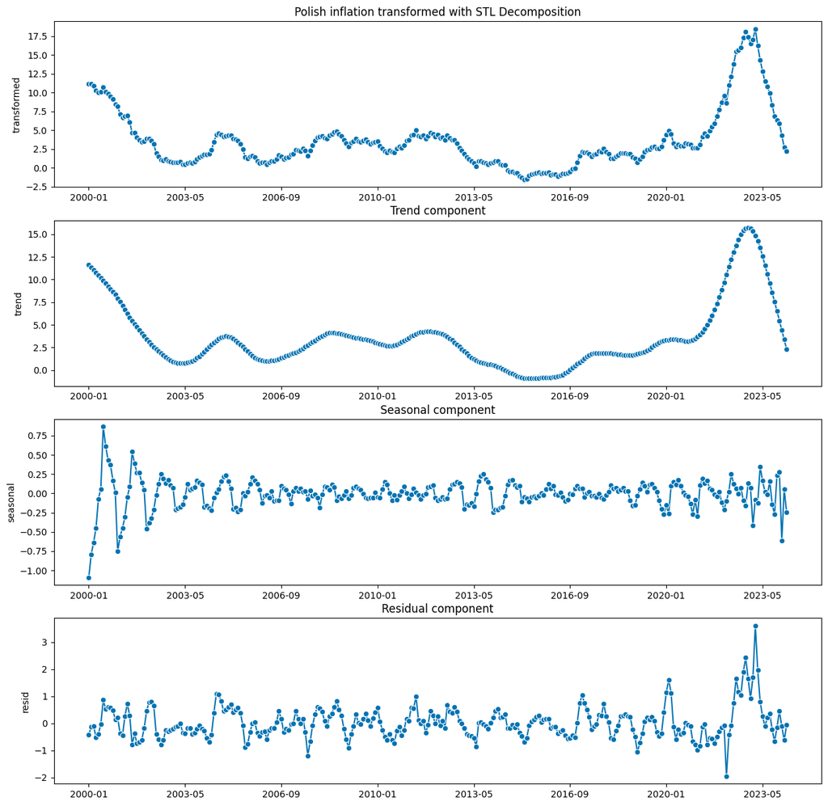

```python
plot_stl_decomposition(df)
```

// skomentuj tutaj

- roczna sezonowość - widać okresowość wzrostów i spadków, natomiast nie jestem pewna, czy jest to faktycznie roczna sezonowość
- rezydua nie wydają się być białym szumem, widać w okolicach 2023 roku wiele informacji do wykorzystania

Metoda "na oko" z dekompozycją STL jest ważna - to pozwala nabrać intuicji i wiedzy co do danych, i walidować parametry. Ale od tego są procedury automatyczne, z testami statystycznymi, żeby nie trzeba było tak ręcznie.

Sprawdźmy teraz, jak wygląda kwestia sezonowości i stacjonarności. Nie jest to stricte potrzebne dla modeli ETS - one przyjmują dane as-is. Natomiast dla modeli ARIMA jest to już niezbędne, bo wymagają danych stacjonarnych, a wiedza o sezonowości potrafi bardzo przyspieszyć obliczenia (SARIMA jest dużo wolniejsza).

**Zadanie 2 (0.75 punktu)**

1. Sprawdź za pomocą testów statystycznych dla sezonowości, czy w danych występuje sezonowość kwartalna, półroczna lub roczna. Przyda się funkcja `nsdiffs` z biblioteki pmdarima. Jeżeli wykryto sezonowość, to usuń ją z pomocą klasy `Differencer` z sktime ([dokumentacja](https://www.sktime.net/en/stable/api_reference/auto_generated/sktime.transformations.series.difference.Differencer.html)) oraz narysuj wartości na wykresie.
2. Sprawdź za pomocą testów statystycznych dla stacjonarności, jaki rząd różnicowania stacjonaryzuje szereg. Przyda się funkcja `ndiffs` z biblioteki pmdarima. Jeżeli jest większy niż zero, to usuń stacjonarość za pomocą klasy `Differencer` i narysuj wykres wartości po różnicowaniu.
3. Skomentuj, z jakiego wariantu modeli ARIMA byś skorzystał i dlaczego, na podstawie obecnej wiedzy: ARMA, ARIMA czy SARIMA.

Skorzystaj z domyślnych wartości `D_max` oraz `d_max`.

**Uwaga:** stwórz tutaj nowe zmienne dla wartości po różnicowaniu, nie nadpisuj `df`. Jeszcze nam się przyda.

**1. Czy w danych występuje sezonowość**

```python
from pmdarima.arima import nsdiffs
```

- nsdiffs -> arg m - The number of seasonal periods -> to liczba oberwacji, która składa się na okres.
- u nas są obserwacje co miesiąc, więc by sprawdzić sezonowość kwartalną, półroczną i roczną, podajemy m = 3, m = 6, m = 12

```python
nsdiffs(df, m=3)
```

```
0
```

```python
nsdiffs(df, m=6)
```

```
0
```

```python
nsdiffs(df, m=12)
```

```
0
```

Jak widzimy, osiągnięte wartości D różnicowania sezonowości są równe 0, czyli nie wykryliśmy sezonowości dla takich potencjalnych okresów sezonowości.

```python
len(df)
```

```
291
```

```python
ds = []
for i in range(len(df)):
    if i <= 1:
        continue
    try:
        d = nsdiffs(df, i)
        if d != 0:
            ds.append((i, d))
    except Exception as e:
        print(e)
```

```
All lag values up to 'maxlag' produced singular matrices. Consider using a longer series, a different lag term or a different test.
shapes (4,2) and (1,) not aligned: 2 (dim 1) != 1 (dim 0)
zero-size array to reduction operation maximum which has no identity
zero-size array to reduction operation maximum which has no identity
zero-size array to reduction operation maximum which has no identity
zero-size array to reduction operation maximum which has no identity
```

```python
ds
```

```
[(260, 1),
 (261, 1),
 (262, 1),
 (266, 1),
 (267, 1),
 (268, 1),
 (269, 1),
 (270, 1),
 (271, 1),
 (276, 1),
 (283, 1),
 (284, 1)]
```

Jak widać, dla całej gamy wartości m nie wykryliśmy sezonowości wgl (poza wzięciem prawie całego szeregu, m bliskie len(df), ale taka interpretacja nie ma sensu). To tak sprawdziłam bardziej z ciekawości.

**2. Rząd różnicowania dla osiągnięcia stacjonarności**

```python
from pmdarima.arima import ndiffs


ndiffs(df)
```

```
1
```

Większy od 0, zatem jest co usuwać.

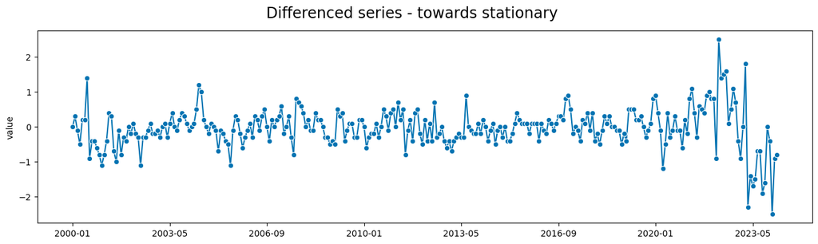

```python
from sktime.transformations.series.difference import Differencer


transformer = Differencer()
df_transformed = transformer.fit_transform(df)
plot_series(df_transformed, title="Differenced series - towards stationary");
```

// skomentuj tutaj

1. Jak widzieliśmy, osiągnięte wartości D różnicowania sezonowości są równe 0, czyli nie wykryliśmy sezonowości dla takich potencjalnych okresów sezonowości.
2. Otrzymany rząd róznicowania był > 0, zatem było co różnicować.
- Po różnicowaniu Differencerem nie osiągnęlismy idealnej stacjonarności, widać, że wariancja jest troszkę nierówna oraz w okolicach roku 2022-2023 widzimy lokalny trend i lokalnie większą wariancję. Ale pewnie ciężko osiągnąć idealną stacjonarność. Jako że udało się wyeliminować trend to jest OK.
- Nie skorzystalibyśmy z SARIMA, ponieważ na podstawie testów statystycznych nie wykryliśmy sezonowości.
- ARIMA = różnicowanie + ARMA, w zasadzie różnicowanie już zrobiliśmy, więc na przetransformowanych danych można zrobić ARMA. Lub pełną ARIMA na oryginalnym szeregu. W każdym razie na podstawie tego zadania widać, że rożnicowanie jest potrzebne dla naszych danych.

Jesteśmy już zasadniczo gotowi do treningu modeli. Do testowania wykorzystamy 20% najnowszych danych, ze strategią expanding window, i krokiem 1 (bo mamy odczyty inflacji co miesiąc). Naszymi metrykami będą MAE, SMAPE oraz MASE.

Wykonamy też analizę rezyduów. Błędy powinny mieć rozkład normalny (model bez biasu) oraz nie mieć autokorelacji (model wykorzystujący całą wiedzę). Na potrzeby wszystkich testów statystycznych zakładamy poziom istotności $\alpha = 0.05$.

Wykorzystamy test normalności Anderson-Darling, bo jest nieco "luźniejszy" niż test Shapiro-Wilk, co jest przydatne w praktyce - błędy rzadko kiedy są bardzo blisko rozkładu normalnego. Hipotezą zerową jest, że wartości pochodzą z danego rozkładu (domyślnie normalnego), a alternatywną, że z jakiegoś innego.

Dla testowania autokorelacji błędów użyjemy testu Ljung-Box, który testuje autokorelację błędów dla różnych lagów. Dla każdego laga ma osobny test, w którym hipotezą zerową jest brak autokorelacji, a hipotezą alternatywą autokorelacja błędów dla danego opóźnienia.

**Zadanie 3 (1.5 punktu)**

Uzupełnij kod funkcji `evaluate_model`:

1. Stwórz `ExpandingWindowSplitter` ([dokumentacja](https://www.sktime.net/en/stable/api_reference/auto_generated/sktime.split.ExpandingWindowSplitter.html)), który zacznie swoje działanie od 80% danych. Wielkość okna wyznacza argument `horizon`.
2. Stwórz listę metryk składającą się z MAE, SMAPE oraz MASE, z biblioteki sktime.
3. Przeprowadź ewaluację modelu za pomocą funkcji `evaluate` ([dokumentacja](https://www.sktime.net/en/stable/api_reference/auto_generated/sktime.forecasting.model_evaluation.evaluate.html)). Przekaż `return_data=True`, żeby zwrócić też obliczone predykcje. Zwraca ona DataFrame z wynikami.
4. Oblicz średnie wartości metryk z wynikowego DataFrame'a. Wypisz je zaokrąglone do 2 miejsc po przecinku.
5. Uwzględniając argument `analyze_residuals`, przeprowadź analizę błędów:
   - oblicz rezydua jako $y - \hat{y}$
   - narysuj histogram rezyduów
   - wykonaj test Anderson-Darling z biblioteki `scipy` i wypisz, czy rozkład jest normalny, czy nie
   - przetestuj test Ljung-Box z biblioteki `statsmodels` i wypisz wyniki testu

Następnie przetestuj tę funkcję na dwóch baseline'ach: średniej oraz ostatniej znanej wartości. Skorzystaj z klasy `NaiveForecaster` ([dokumentacja](https://www.sktime.net/en/stable/api_reference/auto_generated/sktime.forecasting.naive.NaiveForecaster.html)), i horyzontu czasowego 3 miesięcy. Narysuj też wykresy predykcji.

```python
from scipy.stats import anderson
from sktime.forecasting.model_evaluation import evaluate
from sktime.performance_metrics.forecasting import (
    MeanAbsoluteScaledError,
    MeanAbsoluteError,
    MeanAbsolutePercentageError,
)
from sktime.forecasting.model_selection import ExpandingWindowSplitter
from statsmodels.stats.diagnostic import acorr_ljungbox


def evaluate_model(
    model,
    data: pd.Series,
    horizon: int = 1,
    plot_forecasts: bool = False,
    analyze_residuals: bool = False,
) -> None:
    cv = ExpandingWindowSplitter(
        fh=np.arange(1, horizon + 1).tolist(),
        initial_window=int(len(data) * 0.8),
        step_length=horizon,
    )
    metrics = [
        MeanAbsoluteError(),
        MeanAbsolutePercentageError(symmetric=True),
        MeanAbsoluteScaledError(),
    ]
    results = evaluate(
        forecaster=model, y=data, cv=cv, return_data=True, scoring=metrics
    )

    # extract and print metrics
    mae = results["test_MeanAbsoluteError"].mean()
    smape = results["test_MeanAbsolutePercentageError"].mean()
    mase = results["test_MeanAbsoluteScaledError"].mean()

    print(f"MAE: {mae:.2f}")
    print(f"SMAPE: {smape:.2f}")
    print(f"MASE: {mase:.2f}")

    y_pred = pd.concat(results["y_pred"].values)

    if plot_forecasts:
        y_true = data[y_pred.index]
        plot_series(data, y_pred, labels=["y", "y_pred"])
        plt.show()
        plt.clf()

    if analyze_residuals:
        y_true = data[y_pred.index]
        residuals = y_true - y_pred

        # Plot residuals
        residuals.plot(kind="hist", title="Residuals histogram", xlabel="Resiudals")
        plt.show()
        plt.clf()

        # Anderson-Darling
        anderson_res = anderson(residuals)
        print("ANDERSON-DARLING test")
        print("statistic: ", anderson_res.statistic)
        print("critical values: ", anderson_res.critical_values)
        print("significance levels: ", anderson_res.significance_level)
        p_value_idx = 2  # 0.05
        p_value_exceeded = (
            anderson_res.statistic > anderson_res.critical_values[p_value_idx]
        )
        print("p_value_exceeded: ", p_value_exceeded)
        if p_value_exceeded:
            print(
                "The value of the statistic exceeds the critical value "
                + "associated with a significance level of 5% "
                + "so the null hypothesis may be rejected at a significance level of 5%."
            )
            print("Is not normally distributed")
        else:
            print("Is normally distributed")
        print()

        # Ljung-Box
        print("LJUNG-BOX test")
        ljung_box_res = acorr_ljungbox(residuals)
        print(ljung_box_res)
```

```python
from sktime.forecasting.naive import NaiveForecaster


naive_forecaster_mean = NaiveForecaster(strategy="mean")
naive_forecaster_last = NaiveForecaster(strategy="last")
```

```
MAE: 4.88
SMAPE: 0.68
MASE: 14.28
```

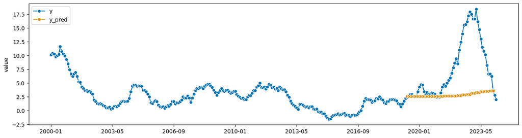

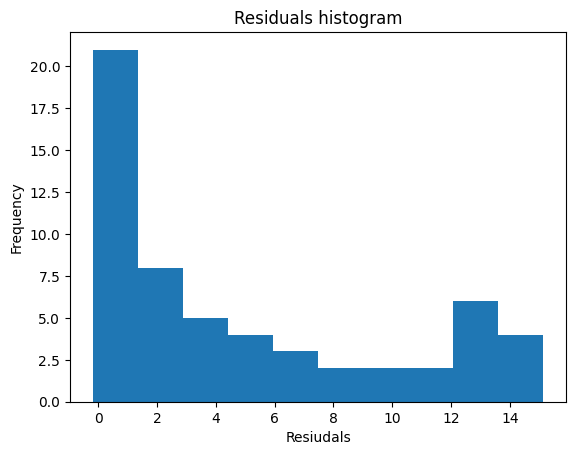

```
ANDERSON-DARLING test
statistic:  3.4993260333375886
critical values:  [0.542 0.617 0.741 0.864 1.028]
significance levels:  [15.  10.   5.   2.5  1. ]
p_value_exceeded:  True
The value of the statistic exceeds the critical value associated with a significance level of 5% so the null hypothesis may be rejected at a significance level of 5%.
Is not normally distributed

LJUNG-BOX test
       lb_stat     lb_pvalue
1    55.918726  7.552972e-14
2   107.968460  3.588780e-24
3   155.302536  1.891395e-33
4   196.706130  1.918615e-41
5   231.552853  4.969873e-48
6   259.624200  3.594285e-53
7   280.958736  7.011050e-57
8   296.303572  2.519357e-59
9   306.715605  9.813835e-61
10  313.270576  2.424750e-61
```

```python
evaluate_model(
    naive_forecaster_mean, df, horizon=3, plot_forecasts=True, analyze_residuals=True
)
```

```
MAE: 1.16
SMAPE: 0.16
MASE: 3.42
```

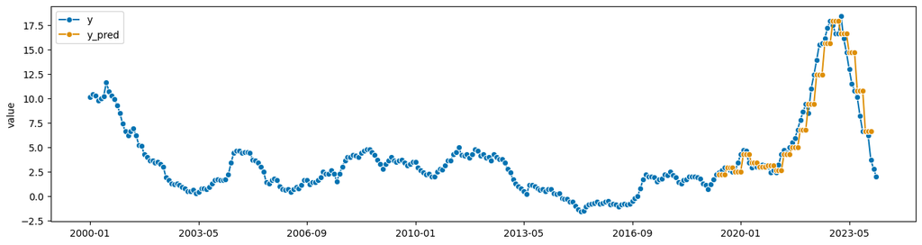

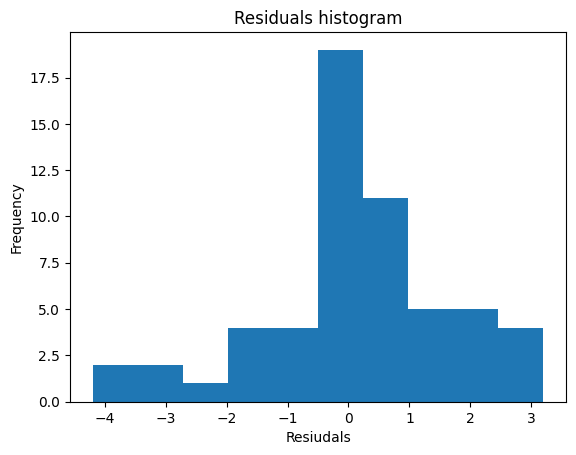

```
ANDERSON-DARLING test
statistic:  0.7799873900236065
critical values:  [0.542 0.617 0.741 0.864 1.028]
significance levels:  [15.  10.   5.   2.5  1. ]
p_value_exceeded:  True
The value of the statistic exceeds the critical value associated with a significance level of 5% so the null hypothesis may be rejected at a significance level of 5%.
Is not normally distributed

LJUNG-BOX test
      lb_stat     lb_pvalue
1   18.524537  1.677311e-05
2   27.638889  9.960736e-07
3   49.204193  1.180207e-10
4   57.566701  9.408561e-12
5   61.882770  4.958834e-12
6   71.435842  2.074685e-13
7   73.880963  2.419379e-13
8   74.161913  7.258231e-13
9   74.593115  1.901313e-12
10  74.641604  5.586540e-12
```

```python
evaluate_model(
    naive_forecaster_last, df, horizon=3, plot_forecasts=True, analyze_residuals=True
)
```

Mamy już pierwsze baseline'y, wyniki z nich wyglądają dość solidnie. Zobaczmy, czy ETS albo ARIMA będą w stanie je przebić.

**Zadanie 4 (0.75 punktu)**

1. Dokonaj predykcji algorytmem AutoETS (klasa `StatsForecastAutoETS`), w wariancie damped trend. Narysuj też predykcje i dokonaj analizy błędów.
2. Analogicznie, dokonaj predykcji algorytmem AutoARIMA (klasa `StatsForecastAutoARIMA`). Jeżeli nie wykryto wcześniej sezonowości, to przekaż odpowiednią opcję, żeby ją wyłączyć - SARIMA jest dużo wolniejsza niż ARIMA.
3. Skomentuj wyniki:
   - czy udało się przebić baseline'y?
   - który z modeli jest lepszy, i o czym może to świadczyć?
   - czy modele są, przynajmniej w przybliżeniu, poprawne, tzn. mają normalne i nieskorelowane błędy?
   - czy wyniki najlepszego modelu są subiektywnie zadowalające?

Wykonaj tutaj predykcje 3-miesięczne, tak jak wcześniej.

**1.**

```python
# %pip install statsforecast>=1.3.2
```

```python
from sktime.forecasting.statsforecast import StatsForecastAutoETS


autoETS = StatsForecastAutoETS(model="ZZZ", damped=True)
```

```
MAE: 0.89
SMAPE: 0.13
MASE: 2.63
```

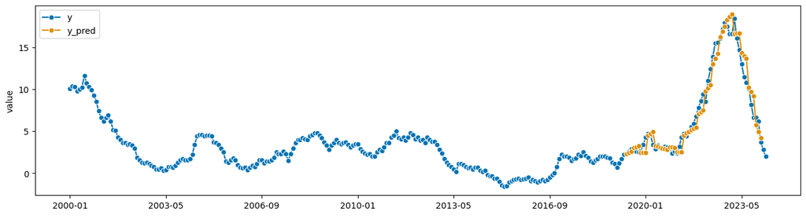

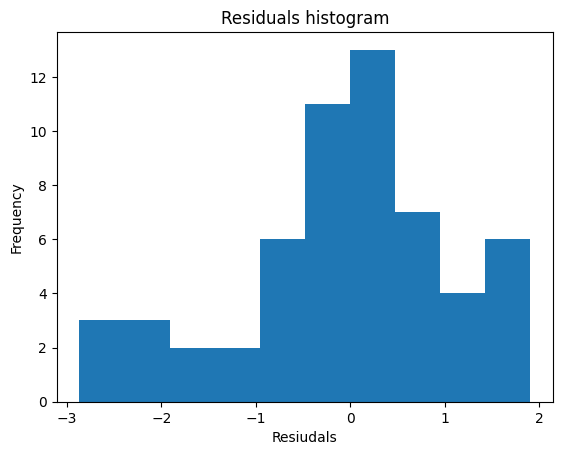

```
ANDERSON-DARLING test
statistic:  0.7190441385047066
critical values:  [0.542 0.617 0.741 0.864 1.028]
significance levels:  [15.  10.   5.   2.5  1. ]
p_value_exceeded:  False
Is normally distributed

LJUNG-BOX test
      lb_stat  lb_pvalue
1   10.054457   0.001520
2   10.829662   0.004450
3   15.897218   0.001190
4   16.984675   0.001946
5   17.836588   0.003158
6   22.724908   0.000894
7   23.427441   0.001436
8   23.563321   0.002712
9   24.705963   0.003314
10  24.769016   0.005801
```

```python
evaluate_model(autoETS, df, horizon=3, plot_forecasts=True, analyze_residuals=True)
```

**2.**

```
MAE: 1.00
SMAPE: 0.14
MASE: 2.96
```

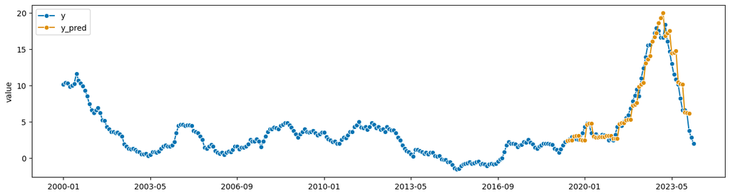

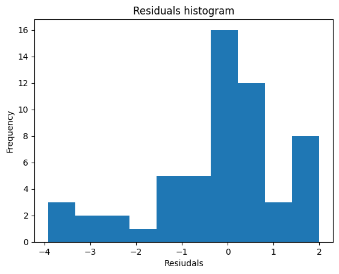

```
ANDERSON-DARLING test
statistic:  1.6868659334403802
critical values:  [0.542 0.617 0.741 0.864 1.028]
significance levels:  [15.  10.   5.   2.5  1. ]
p_value_exceeded:  True
The value of the statistic exceeds the critical value associated with a significance level of 5% so the null hypothesis may be rejected at a significance level of 5%.
Is not normally distributed

LJUNG-BOX test
      lb_stat     lb_pvalue
1   11.225871  8.066490e-04
2   14.320434  7.768861e-04
3   28.809662  2.455437e-06
4   33.120088  1.128729e-06
5   35.984937  9.564232e-07
6   46.744079  2.104440e-08
7   48.728085  2.564961e-08
8   49.098648  6.086874e-08
9   50.720279  7.883792e-08
10  50.855379  1.857077e-07
```

```python
from sktime.forecasting.statsforecast import StatsForecastAutoARIMA


# Seasonality in our time series has not been detected -> set seasonal=False
autoARIMA = StatsForecastAutoARIMA(seasonal=False)
evaluate_model(autoARIMA, df, horizon=3, plot_forecasts=True, analyze_residuals=True)
```

// skomentuj tutaj

- Zarówno w AutoETS, jak i w AutoARIMA udało się przebić obydwa baseline'y.
- Porównanie AutoETS i AutoARIMA - wedle wszystkich 3 metryk lepiej poradził sobie AutoETS. Dodatkowo, w AutoETS udało sie uzyskać rozkład normalny rezyduów (wg testu Andersona-Darlinga). Lepszy wynik AutoETS może łączyć się z tym, że ETS, w przeciwieństwie do ARIMA, nie wymaga stacjonarnych danych - być może nasz szereg nie jest wystarczjąco stacjonarny dla ARIMA.
- Model AutoETS przeszedł test normalności błędów, AutoARIMA nie i tam brak rozkładu normalnego rezyduów jest wyraźnie widoczny na histogramie. Wyniki testu LJung-Box - błędy AutoETS wydają się być bardziej nieskorelowane niż błędy AutoETS.
- Wyniki AutoETS wydają się być zadowalające.

Prognozowanie 3-miesięczne było jednak dość krótkim horyzontem czasowym. Pytanie, co z dalszymi - półrocznym i rocznym. Są one często równie, albo nawet bardziej interesujące, np. w kontekście planowania budżetowego.

**Zadanie 5 (0.75 punktu)**

Dokonaj prognoz dla 6-miesięcznego oraz rocznego horyzontu:

- 2 baseline'ami
- metodami ETS oraz ARIMA
- dla najlepszego modelu narysuj prognozy oraz dokonaj analizy błędów

Skomentuj:

- czy widać jakieś zmiany między modelami w stosunku do przypadku 3-miesięcznego?
- jak zmienia się jakość prognoz przy większych horyzontach czasowych?
- czy te modele dla dłuższych horyzontów są twoim zdaniem użyteczne?

```python
horizons = [6, 12]

naive_forecaster_mean = NaiveForecaster(strategy="mean")
naive_forecaster_last = NaiveForecaster(strategy="last")

autoETS = StatsForecastAutoETS(model="ZZZ", damped=True)
autoARIMA = StatsForecastAutoARIMA(seasonal=False)

models = [naive_forecaster_mean, naive_forecaster_last, autoETS, autoARIMA]

for model in models:
    print(model)
    for h in horizons:
        print(f"\nhorizon={h}\n")
        evaluate_model(model, df, horizon=h)
        print()
    print()
```

```
NaiveForecaster(strategy='mean')

horizon=6

MAE: 5.07
SMAPE: 0.70
MASE: 14.98


horizon=12

MAE: 4.91
SMAPE: 0.68
MASE: 14.95


NaiveForecaster()

horizon=6

MAE: 1.81
SMAPE: 0.24
MASE: 5.41


horizon=12

MAE: 2.18
SMAPE: 0.32
MASE: 6.76


StatsForecastAutoETS(damped=True)

horizon=6

MAE: 1.38
SMAPE: 0.18
MASE: 4.10


horizon=12

MAE: 1.17
SMAPE: 0.17
MASE: 3.67


StatsForecastAutoARIMA(seasonal=False)

horizon=6

MAE: 1.70
SMAPE: 0.20
MASE: 5.03


horizon=12

MAE: 1.37
SMAPE: 0.22
MASE: 4.32
```

Widać, że najlepszym modelem jest StatsForecatAutoETS dla horizon=12 (roczny).

```
MAE: 1.17
SMAPE: 0.17
MASE: 3.67
```

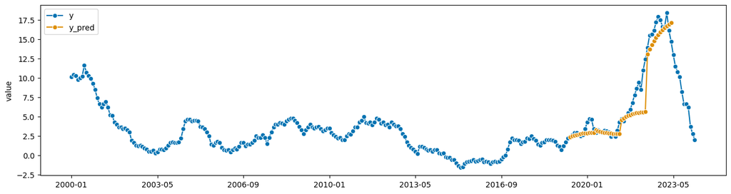

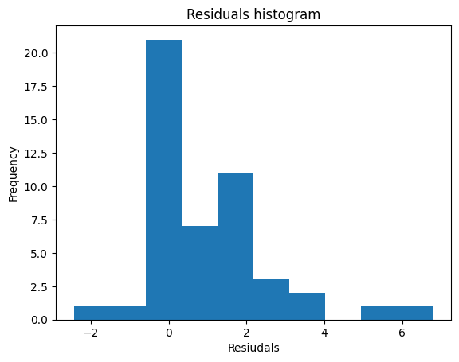

```
ANDERSON-DARLING test
statistic:  2.1805634484268097
critical values:  [0.537 0.612 0.734 0.856 1.018]
significance levels:  [15.  10.   5.   2.5  1. ]
p_value_exceeded:  True
The value of the statistic exceeds the critical value associated with a significance level of 5% so the null hypothesis may be rejected at a significance level of 5%.
Is not normally distributed

LJUNG-BOX test
     lb_stat     lb_pvalue
1  21.542695  3.460383e-06
2  30.909388  1.941385e-07
3  39.940226  1.097052e-08
4  43.820036  6.992387e-09
5  45.474933  1.161567e-08
6  46.242620  2.648867e-08
7  46.598841  6.683425e-08
8  46.608802  1.820502e-07
9  47.038509  3.860366e-07
```

```python
evaluate_model(autoETS, df, horizon=12, plot_forecasts=True, analyze_residuals=True)
```

## Prognozowanie ruchu sieciowego

Teraz zajmiemy się problemem o zupełnie innej charakterystyce - prognozowaniem ruchu sieciowego. Jest to kluczowe zadanie pod kątem skalowania serwerów, coraz częściej realizowane z pomocą właśnie prognozowania szeregów czasowych. Tzw. predictive scaling implementują między innymi [AWS](https://docs.aws.amazon.com/autoscaling/ec2/userguide/ec2-auto-scaling-predictive-scaling.html), [GCP](https://cloud.google.com/compute/docs/autoscaler/predictive-autoscaling) i [Azure](https://learn.microsoft.com/en-us/azure/azure-monitor/autoscale/autoscale-predictive), istnieją także rozwiązania dla Kubernetesa, [open source](https://predictive-horizontal-pod-autoscaler.readthedocs.io/en/latest/), oraz [komercyjne](https://keda.sh/blog/2022-02-09-predictkube-scaler/). Prognozowanie szeregów czasowych pozwala proaktywnie dokładać kolejne maszyny wirtualne, aby przygotować się na zwiększony ruch i zapewnić niskie opóźnienia, oraz redukuje koszty, automatycznie wyłączając je przy przewidywanym małym ruchu.

Wikipedia i Google hostowały [konkurs na platformie Kaggle](https://www.kaggle.com/c/web-traffic-time-series-forecasting), w którym zadaniem było prognozowanie ruchu na poszczególnych stronach. Jest on dość kolosalny, dlatego na jego podstawie przygotowano uproszczony, w którym mamy zapisaną sumaryczną liczbę requestów do Wikipedii, liczoną w milionach.

Charakterystyki takiego zadania to typowo:

- krótkoterminowe prognozy
- duża częstotliwość danych
- dynamicznie zmienne i zaszumione dane (np. przez aktywność botów)
- bardzo częsty retrening modeli
- duża potrzeba automatyzacji, brak ręcznej analizy modeli

|  | value |
| --- | --- |
| 2015-07-01 | 148.672476 |
| 2015-07-02 | 149.593840 |
| 2015-07-03 | 141.164198 |
| 2015-07-04 | 145.612937 |
| 2015-07-05 | 151.495372 |
| ... | ... |
| 2017-09-06 | 172.354146 |
| 2017-09-07 | 180.731284 |
| 2017-09-08 | 136.754670 |
| 2017-09-09 | 132.359512 |
| 2017-09-10 | 141.863949 |

803 rows × 1 columns

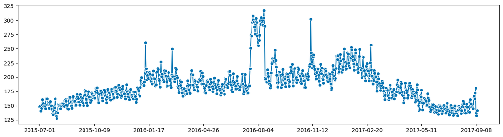

```python
df = pd.read_parquet("wikipedia_traffic.parquet")
df = df.set_index("date").to_period(freq="d")
plot_series(df)
df
```

**Zadanie 6 (1 punkt)**

Zakładając horyzont 1 dnia, wytrenuj modele i dokonaj ich ewaluacji (analogicznie do poprzedniego zbioru danych):

- 2 modele baseline'owe
- model ETS (z damped trend)
- model ARIMA (bez sezonowości)
- model SARIMA

Skomentuj:

- czy z tych wyników można wnioskować, że mamy tu sezonowość?
- czy udało się przebić baseline?

```python
from sktime.forecasting.naive import NaiveForecaster
from sktime.forecasting.statsforecast import (
    StatsForecastAutoETS,
    StatsForecastAutoARIMA,
)


naive_forecaster_mean = NaiveForecaster(strategy="mean")
naive_forecaster_last = NaiveForecaster(strategy="last")

autoETS = StatsForecastAutoETS(model="ZZZ", damped=True)
autoARIMA = StatsForecastAutoARIMA(seasonal=False)
autoSARIMA = StatsForecastAutoARIMA()
```

Little technical fix to evaluate_model func.

```python
from scipy.stats import anderson
from sktime.forecasting.model_evaluation import evaluate
from sktime.performance_metrics.forecasting import (
    MeanAbsoluteScaledError,
    MeanAbsoluteError,
    MeanAbsolutePercentageError,
)
from sktime.forecasting.model_selection import ExpandingWindowSplitter
from statsmodels.stats.diagnostic import acorr_ljungbox


# Little technical fix
def evaluate_model_2(
    model,
    data: pd.Series,
    horizon: int = 1,
    plot_forecasts: bool = False,
    analyze_residuals: bool = False,
) -> None:
    cv = ExpandingWindowSplitter(
        fh=np.arange(1, horizon + 1).tolist(),
        initial_window=int(len(data) * 0.8),
        step_length=horizon,
    )
    metrics = [
        MeanAbsoluteError(),
        MeanAbsolutePercentageError(symmetric=True),
        MeanAbsoluteScaledError(),
    ]
    results = evaluate(
        forecaster=model, y=data, cv=cv, return_data=True, scoring=metrics
    )

    # extract and print metrics
    mae = results["test_MeanAbsoluteError"].mean()
    smape = results["test_MeanAbsolutePercentageError"].mean()
    mase = results["test_MeanAbsoluteScaledError"].mean()

    print(f"MAE: {mae:.2f}")
    print(f"SMAPE: {smape:.2f}")
    print(f"MASE: {mase:.2f}")

    y_pred = pd.concat(results["y_pred"].values)
    y_true = data.loc[y_pred.index]

    if plot_forecasts:
        plot_series(data, y_pred, labels=["y", "y_pred"])
        plt.show()
        plt.clf()

    if analyze_residuals:
        residuals = y_true - y_pred
        # to pd.Series
        residuals = residuals.iloc[:, 0]

        # Plot residuals
        residuals.plot(kind="hist", title="Residuals histogram", xlabel="Resiudals")
        plt.show()
        plt.clf()

        # Anderson-Darling
        anderson_res = anderson(residuals)
        print("ANDERSON-DARLING test")
        print("statistic: ", anderson_res.statistic)
        print("critical values: ", anderson_res.critical_values)
        print("significance levels: ", anderson_res.significance_level)
        p_value_idx = 2  # 0.05
        p_value_exceeded = (
            anderson_res.statistic > anderson_res.critical_values[p_value_idx]
        )
        print("p_value_exceeded: ", p_value_exceeded)
        if p_value_exceeded:
            print(
                "The value of the statistic exceeds the critical value "
                + "associated with a significance level of 5% "
                + "so the null hypothesis may be rejected at a significance level of 5%."
            )
            print("Is not normally distributed")
        else:
            print("Is normally distributed")
        print()

        # Ljung-Box
        print("LJUNG-BOX test")
        ljung_box_res = acorr_ljungbox(residuals)
        print(ljung_box_res)
```

```
--------------------
NaiveForecaster(strategy='mean')
MAE: 33.04
SMAPE: 0.20
MASE: 3.92
```

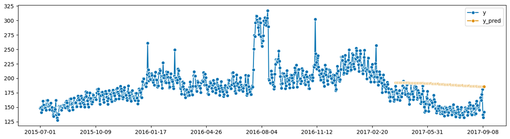

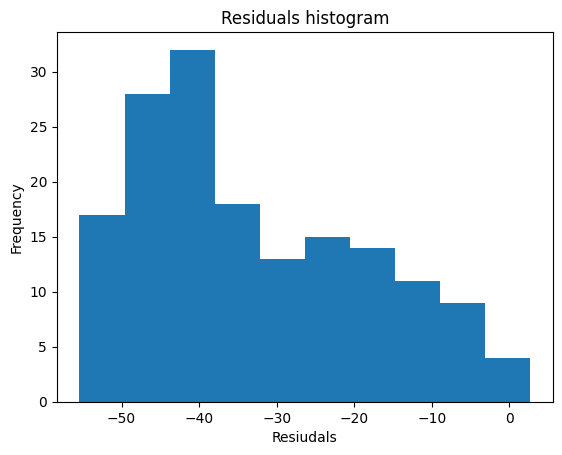

```
ANDERSON-DARLING test
statistic:  2.556700018983065
critical values:  [0.563 0.641 0.769 0.897 1.067]
significance levels:  [15.  10.   5.   2.5  1. ]
p_value_exceeded:  True
The value of the statistic exceeds the critical value associated with a significance level of 5% so the null hypothesis may be rejected at a significance level of 5%.
Is not normally distributed

LJUNG-BOX test
       lb_stat      lb_pvalue
1   107.211808   4.000461e-25
2   164.856081   1.592050e-36
3   205.413344   2.853728e-44
4   242.053144   3.351831e-51
5   284.435356   2.218267e-59
6   353.959889   2.179278e-73
7   447.215758   1.759278e-92
8   522.345683  1.126437e-107
9   569.445528  7.527675e-117
10  602.901149  4.208371e-123

--------------------
NaiveForecaster()
MAE: 6.63
SMAPE: 0.04
MASE: 0.78
```

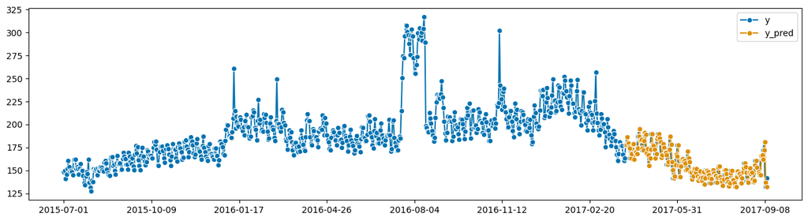

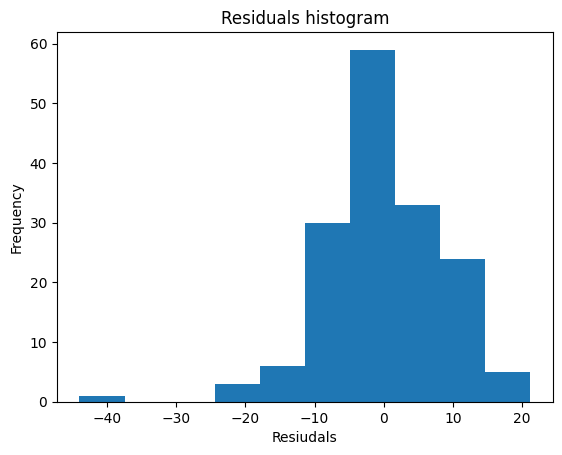

```
ANDERSON-DARLING test
statistic:  0.7436284207647645
critical values:  [0.563 0.641 0.769 0.897 1.067]
significance levels:  [15.  10.   5.   2.5  1. ]
p_value_exceeded:  False
Is normally distributed

LJUNG-BOX test
      lb_stat     lb_pvalue
1    0.851959  3.559988e-01
2   18.249244  1.089500e-04
3   22.265225  5.744549e-05
4   26.428291  2.593524e-05
5   42.202876  5.359016e-08
6   43.893069  7.761925e-08
7   84.423276  1.720217e-15
8   89.729864  5.276265e-16
9   94.433234  2.091518e-16
10  98.009649  1.362639e-16

--------------------
StatsForecastAutoETS(damped=True)
MAE: 6.63
SMAPE: 0.04
MASE: 0.78
```

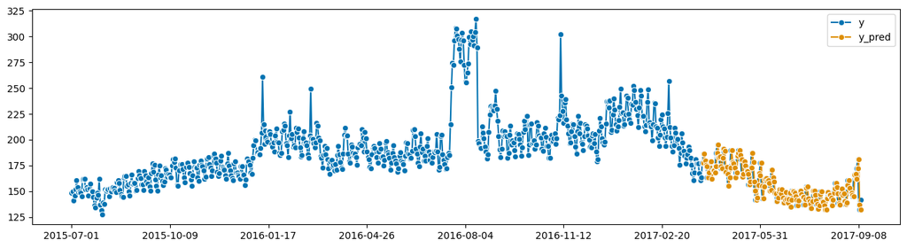

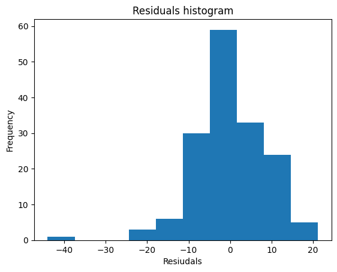

```
ANDERSON-DARLING test
statistic:  0.7436139722164512
critical values:  [0.563 0.641 0.769 0.897 1.067]
significance levels:  [15.  10.   5.   2.5  1. ]
p_value_exceeded:  False
Is normally distributed

LJUNG-BOX test
      lb_stat     lb_pvalue
1    0.853388  3.555958e-01
2   18.251491  1.088276e-04
3   22.269861  5.731798e-05
4   26.435488  2.584862e-05
5   42.210510  5.339981e-08
6   43.901230  7.733060e-08
7   84.434408  1.711220e-15
8   89.742416  5.245404e-16
9   94.445480  2.079674e-16
10  98.023626  1.353905e-16

--------------------
StatsForecastAutoARIMA(seasonal=False)
MAE: 5.54
SMAPE: 0.03
MASE: 0.65
```

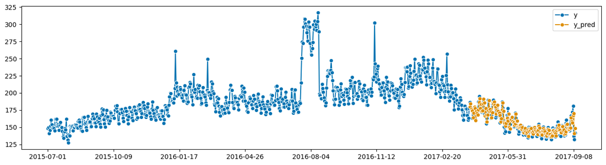

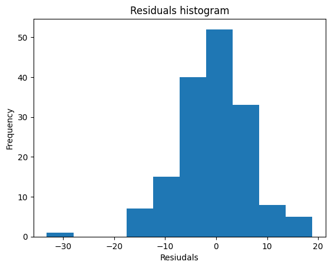

```
ANDERSON-DARLING test
statistic:  0.4993705572860563
critical values:  [0.563 0.641 0.769 0.897 1.067]
significance levels:  [15.  10.   5.   2.5  1. ]
p_value_exceeded:  False
Is normally distributed

LJUNG-BOX test
      lb_stat  lb_pvalue
1    0.152877   0.695801
2    3.107689   0.211434
3    3.524975   0.317537
4    4.777191   0.310932
5   14.052782   0.015278
6   14.296274   0.026496
7   29.916060   0.000098
8   31.502722   0.000114
9   33.331793   0.000117
10  33.437057   0.000230

--------------------
StatsForecastAutoARIMA()
MAE: 5.54
SMAPE: 0.03
MASE: 0.65
```

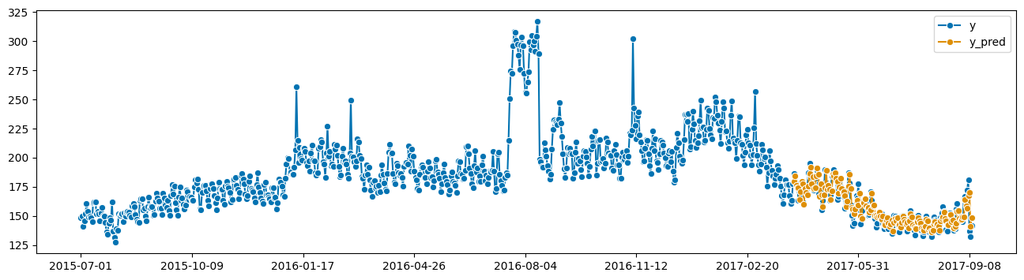

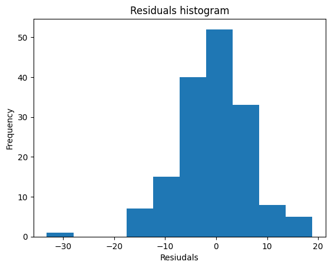

```
ANDERSON-DARLING test
statistic:  0.4993705572860563
critical values:  [0.563 0.641 0.769 0.897 1.067]
significance levels:  [15.  10.   5.   2.5  1. ]
p_value_exceeded:  False
Is normally distributed

LJUNG-BOX test
      lb_stat  lb_pvalue
1    0.152877   0.695801
2    3.107689   0.211434
3    3.524975   0.317537
4    4.777191   0.310932
5   14.052782   0.015278
6   14.296274   0.026496
7   29.916060   0.000098
8   31.502722   0.000114
9   33.331793   0.000117
10  33.437057   0.000230
```

```python
from termcolor import colored


models = [naive_forecaster_mean, naive_forecaster_last, autoETS, autoARIMA, autoSARIMA]

for model in models:
    print("--------------------")
    print(colored(model, "blue"))
    evaluate_model_2(model, df, horizon=1, plot_forecasts=True, analyze_residuals=True)
    print()
```

- Puściliśmy ARIMA (AutoARIMA z arg. seasonal=False) oraz SARIMA (AutoArima z arg. seasonal=True) i dały te same rezultaty dla wszystkich 3 metryk => możemy z tego wnioskowac, że nie ma sezonowości.
- ETS nie udało sie przebić baseline'u, wynik był dokładnie taki sam dla NaiveForecaster(strategy="last"). ARIMA i SARIMA dały dokładnie ten sam rezultat i przebiły baseline.

Może jednak da się lepiej? Nasze dane mają bardzo dużą zmienność, a więc wariancję, a modele ARIMA tego nie lubią. Zastosujmy więc transformacje stabilizujące wariancję. Mamy tu same dodatnie wartości, więc nie będzie tu problemów numerycznych i można używać dowolnych operacji.

Trzeba tutaj wykorzystać `Pipeline` z sktime, bo automatycznie odwróci on wszystkie operacje podczas predykcji. Czasem dokonuje się ewaluacji danych po transformacji, ale typowo interesuje nas jakość na pierwotnych danych. Przekształcenia służą tylko do poprawienia treningu.

**Zadanie 7 (0.5 punktu)**

Stwórz pipeline, składający się z transformacji oraz modelu AutoARIMA (bez sezonowości). Wypróbuj transformacje:

- log
- sqrt
- Box-Cox

Przedstaw na wykresie oraz pierwotny szereg czasowy szereg po transformacji dającej najlepszy wynik.

Funkcję `make_pipeline` oraz klasy implementujące transformacje znajdziesz w sktime.

Skomentuj:

- czy udało się poprawić wynik transformacją?
- oceniając wizualnie, czy udało się ustabilizować wariancję?

```python
from sktime.pipeline import make_pipeline
from sktime.transformations.series.boxcox import LogTransformer
from sktime.transformations.series.exponent import SqrtTransformer
from sktime.transformations.series.boxcox import BoxCoxTransformer


model = StatsForecastAutoARIMA(seasonal=False)

pipe_log = make_pipeline(LogTransformer(), model)
pipe_sqrt = make_pipeline(SqrtTransformer(), model)
pipe_box_cox = make_pipeline(BoxCoxTransformer(), model)
```

```
--------------------
pipe_log
MAE: 5.35
SMAPE: 0.03
MASE: 0.63
```

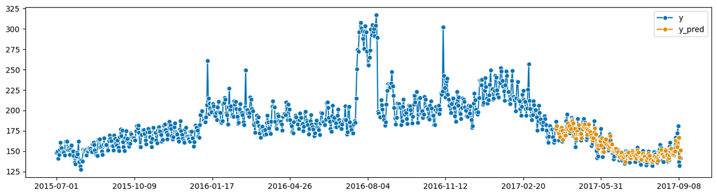

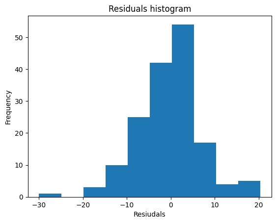

```
ANDERSON-DARLING test
statistic:  1.0369001379050076
critical values:  [0.563 0.641 0.769 0.897 1.067]
significance levels:  [15.  10.   5.   2.5  1. ]
p_value_exceeded:  True
The value of the statistic exceeds the critical value associated with a significance level of 5% so the null hypothesis may be rejected at a significance level of 5%.
Is not normally distributed

LJUNG-BOX test
      lb_stat  lb_pvalue
1    2.739562   0.097892
2    2.828174   0.243148
3    3.472403   0.324359
4    6.504590   0.164501
5   12.253454   0.031475
6   13.328374   0.038108
7   21.150021   0.003554
8   22.606883   0.003907
9   23.730284   0.004749
10  24.523171   0.006326

--------------------
pipe_sqrt
MAE: 5.29
SMAPE: 0.03
MASE: 0.63
```

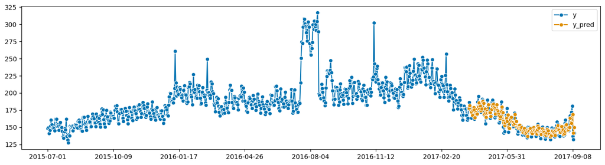

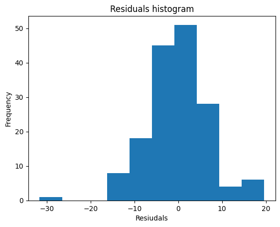

```
ANDERSON-DARLING test
statistic:  0.9917916317880895
critical values:  [0.563 0.641 0.769 0.897 1.067]
significance levels:  [15.  10.   5.   2.5  1. ]
p_value_exceeded:  True
The value of the statistic exceeds the critical value associated with a significance level of 5% so the null hypothesis may be rejected at a significance level of 5%.
Is not normally distributed

LJUNG-BOX test
      lb_stat  lb_pvalue
1    1.402586   0.236291
2    1.866467   0.393280
3    2.409878   0.491798
4    4.738800   0.315163
5   10.740549   0.056774
6   11.570147   0.072275
7   20.592112   0.004423
8   21.989393   0.004936
9   23.342857   0.005471
10  24.028003   0.007526

--------------------
pipe_box_cox
MAE: 5.64
SMAPE: 0.04
MASE: 0.67
```

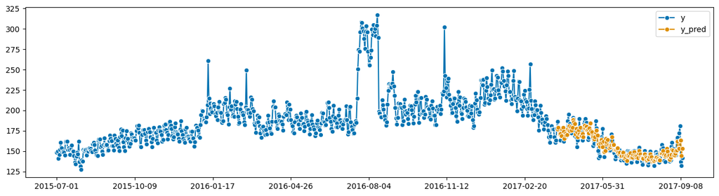

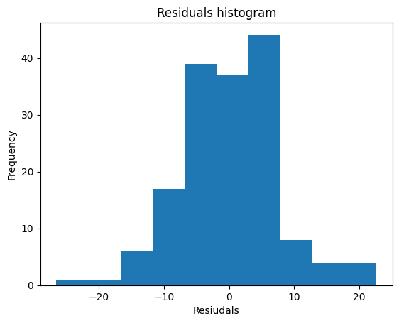

```
ANDERSON-DARLING test
statistic:  1.1242264268811937
critical values:  [0.563 0.641 0.769 0.897 1.067]
significance levels:  [15.  10.   5.   2.5  1. ]
p_value_exceeded:  True
The value of the statistic exceeds the critical value associated with a significance level of 5% so the null hypothesis may be rejected at a significance level of 5%.
Is not normally distributed

LJUNG-BOX test
      lb_stat  lb_pvalue
1    9.500056   0.002055
2    9.703827   0.007813
3   11.057151   0.011421
4   17.150142   0.001807
5   23.305529   0.000295
6   24.628311   0.000400
7   31.194693   0.000057
8   33.153817   0.000058
9   33.888793   0.000093
10  35.351879   0.000109
```

```python
pipes = [pipe_log, pipe_sqrt, pipe_box_cox]
names = ["pipe_log", "pipe_sqrt", "pipe_box_cox"]

for i, pipe in enumerate(pipes):
    print("--------------------")
    print(colored(names[i], "blue"))
    evaluate_model_2(pipe, df, horizon=1, plot_forecasts=True, analyze_residuals=True)
    print()
```